# Crude Oil Production and Evacuation Analytics: Drivers of Zone-Level Throughput Performance

Author

Abiba Badmus — 2026/31/E/1647

Published

May 20, 2026

## 1 Executive Summary

This analysis identifies where daily crude oil production losses are occurring across OML 18 and quantifies which operational levers can most effectively close the gap against plan. The analysis covers two internal datasets extracted from OML 18 systems (January 1 – May 5, 2026): 625 station-level production records across four active flow stations in two evacuation zones, and 250 zone-level evacuation capacity records. Five techniques — EDA, visualization, hypothesis testing, correlation, and regression — are applied in sequence to build from description to quantified recommendation.

Findings show persistent, system-wide underperformance: 86.4% of station-days fall below budget. Zone differences are directionally present but not statistically robust (Kruskal-Wallis p = 0.195); station-level differences, however, are highly significant (ANOVA F = 32.6, p < 0.001), with CC2 the deepest underperformer. Correlation and regression both identify evacuation capacity as the primary modifiable lever (r = −0.36 with shortfall; regression coefficient = −0.56 bbl/day shortfall per 1 bbl/day capacity, p < 0.001). The model explains 29% of shortfall variance, so recommendations are expressed as conditional operational projections, not causal guarantees.

## 2 Professional Disclosure

**Job title:** Head, Alternative Crude Oil Evacuation **Organisation sector:** Upstream oil and gas operations — national crude production, zone-level throughput management, and evacuation logistics

### 2.1 Exploratory Data Analysis

As Head of Alternative Crude Oil Evacuation, every working day begins with a review of the previous day’s production figures: did each flow station meet its `BUDGET` target, and what is the gap in `ACTUAL`? Before any statistical test can be run, I need to understand the distributional shape of that gap across 625 daily records spanning four flow stations (ALK, CC1, CC2, CC3) and two zones. Are shortfalls concentrated in certain stations or spread evenly? Are there extreme outlier days — caused by pipeline maintenance or force majeure — that would distort any zone-level comparison? EDA answers these questions first and ensures that every downstream test and model rests on verified, understood data rather than unexamined assumptions. This mirrors the operational health-check I conduct before presenting production performance to senior management.

**Alternative considered:** Jumping directly to regression on the combined dataset. Rejected because undetected outliers in `ACTUAL` (including blank/zero values in early January) would silently bias regression coefficients and produce misleading conclusions about which zones are genuinely underperforming.

**Limitation:** EDA is descriptive only. A zone that visually appears to underperform may still fail to do so significantly once sample variance is accounted for. Formal tests are required before drawing operational conclusions.

### 2.2 Data Visualization

Upstream operations leadership does not make decisions from tables of numbers. The briefings I prepare for management are built around time-series charts of daily `ACTUAL` vs `BUDGET` production, zone-level comparison charts, and capacity utilization trend lines drawn from `evacuation_capacity` and `evacuation_utilization`. The `DATE` field enables a full January–May 2026 timeline view, while `ZONE` and `FLOW_STATIONS` provide the categorical groupings needed for comparison. Visualization allows me to spot bottleneck periods — weeks where Zone 1 (CC2/CC3) and Zone 2 (ALK/CC1) diverge — in a format that a non-technical executive can act on immediately. These charts are directly reusable in production performance briefings.

**Alternative considered:** Summary statistics tables only. Rejected because tables do not communicate temporal patterns or cross-zone divergence, precisely the patterns that matter most for evacuation scheduling decisions.

**Limitation:** Visual patterns can appear more decisive than they are. A chart showing Zone 2 consistently below budget could be driven by one outlier period. All visual findings are followed by formal hypothesis tests before policy action is recommended.

### 2.3 Hypothesis Testing

My organisation operates four flow stations across two zones, and a persistent management question is whether Zone 1 and Zone 2 perform statistically differently against their respective `BUDGET` targets, or whether the apparent difference is within normal operational variance. If the difference is statistically significant, that is a resource allocation issue: it justifies redirecting evacuation capacity or maintenance attention to the underperforming zone. If it is not significant, the variability is systemic and calls for a different intervention. A p-value and effect size turn what is currently an informal management opinion into a defensible, data-backed operational directive.

**Alternative considered:** Kruskal-Wallis non-parametric test as the primary method, since daily production data can exhibit skew. This is run as a robustness check alongside parametric ANOVA — as it turns out, the non-parametric result overrides the parametric one.

**Limitation:** After splitting by both `ZONE` and `FLOW_STATIONS`, some station-level subgroups may have fewer observations than ideal for high-power comparisons. Zone-level comparisons are adequately powered; station-level results are interpreted with explicit power caveats.

### 2.4 Correlation Analysis

Before including `evacuation_capacity` and `evacuation_utilization` as predictors in regression, I need to establish whether they are actually related to production performance. My operational hypothesis is that low utilization relative to capacity should correlate with better production attainment. Correlation analysis on the merged daily dataset confirms or refutes this and reveals which evacuation variables are worth including as predictors. It also guards against multicollinearity. Given the confirmed non-normality of shortfall distributions (Shapiro-Wilk p < 0.05), Spearman rank correlation is the primary non-parametric measure; Pearson is reported alongside for direct comparison.

**Alternative considered:** Entering all evacuation and production variables directly into regression without prior screening. Rejected because this produces inflated standard errors and misleading coefficient signs when predictors are correlated.

**Limitation:** Correlation measures linear (Pearson) or monotonic (Spearman) association only. The relationship between evacuation utilization and production attainment may be non-linear — utilization below 40% may have limited impact while utilization above 80% may sharply constrain output. This is explored visually before regression specification.

### 2.5 Multiple Regression

The commercial and strategic purpose of this analysis is a daily production attainment model: given a station’s `BUDGET` target, its `ZONE`, its `evacuation_capacity`, and its `utilization_rate`, what `ACTUAL` production shortfall should be expected? A regression equation with `shortfall` as the outcome variable provides coefficient-level answers to the question every evacuation planning meeting asks: which factor, if improved by one unit, recovers the most daily barrels? Every coefficient in this model maps to a recoverable share of annual throughput targets.

**Alternative considered:** Random forest regression to capture non-linear interactions between zone, station, and capacity variables. Rejected because the current dataset is relatively small for stable ensemble generalisation and the output would be less interpretable for management briefing.

**Limitation:** The regression assumes approximately linear relationships between predictors and shortfall. If the true relationship is threshold-based — for example, output only suffers once capacity falls below a critical level — diagnostic plots will reveal this and a transformed specification can be applied.

## 3 Data Collection & Sampling

| Attribute | Detail |
| --- | --- |
| **Source system** | Internal daily production and evacuation reporting — OML 18 (Oil Mining Lease 18) Upstream Operations |
| **Zone structure** | Zone 1: CC2, CC3 · Zone 2: ALK, CC1. Three additional planned stations are non-operational and excluded |
| **Dataset 1** | `daily production report.csv` — 625 station-day records, flow-station budget vs actual production |
| **Dataset 2** | `evacuation_report.csv` — 250 zone-day records, evacuation capacity and utilization |
| **Time period** | 1 January – 5 May 2026 (125 calendar days; May 2026 partial — 5 days only) |
| **Collection method** | Direct extraction from internal operational reporting system; author holds system access as accountability holder |
| **Sample frame** | Full operational population — no sampling; all active flow stations and zones included |
| **Selection bias** | None deliberate. Zero/blank `ACTUAL` values in early January treated as non-operational periods, not collection errors |
| **Anonymisation** | Flow-station codes and zone designators are internal operational names; no employee or customer PII present |
| **Ethical clearance** | Internal line management approval and data-governance clearance obtained for academic use of operational aggregates |
| **Restrictions** | Company-confidential absolute volume figures anonymised; relative ratios and shortfall statistics are publishable under internal approval |

### 3.1 Data Governance, Extraction Workflow, and Sampling Justification

- **System of record and extraction pipeline:** Daily production and evacuation records were exported from internal OML 18 operational reporting modules and saved as controlled CSV snapshots (`daily production report.csv`, `evacuation_report.csv`) used in this analysis.
- **Extraction governance:** The extraction event, approver identity, and approval reference are logged in the internal operations audit trail maintained by the line function; only aggregate operational fields were exported for academic use.
- **Privacy and confidentiality:** No direct personal identifiers or employee-level fields are present. Flow-station and zone labels are operational asset codes; absolute sensitive commercial values are not disclosed outside approved internal channels.
- **Sampling frame rationale:** This is a full operational census of active assets over the covered period (Jan 1-May 5, 2026), not a sampled subset. For zone-level comparisons, the effective group sizes are sufficient for stable inference on medium effects, while the observed zone effect (eta-squared = 0.007) is substantively negligible regardless of statistical significance under alternative assumptions.
- **Partial-Period Bias:** Because May covers only 5 days, formal trend inference is reported both with and without partial-May observations to avoid overstating deterioration.

## 4 Data Description

### 4.1 Variable Dictionary

| Variable | Source | Type | Unit | Description |
| --- | --- | --- | --- | --- |
| `DATE` | Both | Date | YYYY-MM-DD | Calendar date of observation |
| `ZONE` | Both | Categorical | — | Evacuation zone (Zone 1 / Zone 2) |
| `FLOW_STATIONS` | Production | Categorical | — | Flow station code: ALK, CC1, CC2, CC3 |
| `BUDGET` | Production | Numeric | bbl/day | Planned production target for the station-day |
| `ACTUAL` | Production | Numeric | bbl/day | Realised production for the station-day |
| `shortfall` | Derived | Numeric | bbl/day | `ACTUAL − BUDGET`; negative = underperformance |
| `evacuation_capacity` | Evacuation | Numeric | bbl/day | Maximum daily volume the alternative route can carry |
| `evacuation_utilization` | Evacuation | Numeric | bbl/day | Actual daily volume moved via alternative route |
| `utilization_rate` | Derived | Numeric | ratio | `evacuation_utilization / evacuation_capacity` |
| `BUDGET_zone` | Derived | Numeric | bbl/day | Sum of station budgets within zone-day |
| `ACTUAL_zone` | Derived | Numeric | bbl/day | Sum of station actuals within zone-day |
| `shortfall_zone` | Derived | Numeric | bbl/day | Zone-day shortfall = `ACTUAL_zone − BUDGET_zone` |

**R**

```r
cat("Production records:", nrow(prod_r), "rows |", ncol(prod_r), "columns\n")
```

```
Production records: 625 rows | 6 columns
```

```r
cat("Evacuation records:", nrow(evac_r), "rows |", ncol(evac_r), "columns\n")
```

```
Evacuation records: 250 rows | 5 columns
```

```r
cat("Merged zone dataset:", nrow(df_r), "rows\n\n")
```

```
Merged zone dataset: 250 rows
```

```r
prod_r |>
  select(BUDGET, ACTUAL, shortfall) |>
  summary() |>
  kable(caption = "Production dataset — key numeric summaries") |>
  kable_styling(bootstrap_options = "striped", full_width = FALSE)
```

Production dataset — key numeric summaries

|  | BUDGET | ACTUAL | shortfall |
| --- | --- | --- | --- |
|  | Min. : 2500 | Min. : 0 | Min. :-9389.3 |
|  | 1st Qu.: 5000 | 1st Qu.: 3214 | 1st Qu.:-3504.1 |
|  | Median : 8000 | Median : 6428 | Median :-1694.9 |
|  | Mean : 8783 | Mean : 6733 | Mean :-2050.7 |
|  | 3rd Qu.:13000 | 3rd Qu.: 9236 | 3rd Qu.: -559.3 |
|  | Max. :22000 | Max. :18842 | Max. : 3322.9 |

```r
prod_r |>
  summarise(across(everything(), ~ sum(is.na(.)))) |>
  pivot_longer(everything(), names_to = "Column", values_to = "NA_count") |>
  filter(NA_count > 0) |>
  kable(caption = "Missing values in production dataset") |>
  kable_styling(full_width = FALSE)
```

Missing values in production dataset

| Column | NA_count |
| --- | --- |

```r
cat("\nNote: ACTUAL = 0 records (non-operational days):",
    sum(prod_r$ACTUAL == 0), "\n")
```

```
Note: ACTUAL = 0 records (non-operational days): 34
```

```r
prod_r |>
  count(ZONE, FLOW_STATIONS) |>
  kable(caption = "Record counts by Zone and Flow Station") |>
  kable_styling(full_width = FALSE)
```

Record counts by Zone and Flow Station

| ZONE | FLOW_STATIONS | n |
| --- | --- | --- |
| ZONE 1 | CC2 | 250 |
| ZONE 1 | CC3 | 125 |
| ZONE 2 | ALK | 125 |
| ZONE 2 | CC1 | 125 |

**Python**

```python
print(f"Production records: {prod_py.shape[0]} rows | {prod_py.shape[1]} columns")
```

```
Production records: 625 rows | 6 columns
```

```python
print(f"Evacuation records: {evac_py.shape[0]} rows | {evac_py.shape[1]} columns")
```

```
Evacuation records: 250 rows | 5 columns
```

```python
print(f"Merged zone dataset: {df_py.shape[0]} rows\n")
```

```
Merged zone dataset: 250 rows
```

```python
display(prod_py[["BUDGET", "ACTUAL", "shortfall"]].describe().round(2))
```

```
         BUDGET    ACTUAL  shortfall
count    625.00    625.00     625.00
mean    8783.20   6732.50   -2050.70
std     5033.68   4360.23    2239.46
min     2500.00      0.00   -9389.29
25%     5000.00   3214.50   -3504.14
50%     8000.00   6428.24   -1694.86
75%    13000.00   9235.63    -559.29
max    22000.00  18841.80    3322.87
```

```python
na_counts = prod_py.isnull().sum()
na_counts = na_counts[na_counts > 0]
if len(na_counts):
    print("Missing values:\n", na_counts)
else:
    print("No missing values after cleaning.\n")
```

```
No missing values after cleaning.
```

```python
print(f"ACTUAL = 0 records (non-operational days): {(prod_py['ACTUAL'] == 0).sum()}")
```

```
ACTUAL = 0 records (non-operational days): 34
```

```python
print("\nRecord counts by Zone and Flow Station:")
```

```
Record counts by Zone and Flow Station:
```

```python
display(prod_py.groupby(["ZONE", "FLOW_STATIONS"]).size().reset_index(name="count"))
```

```
     ZONE FLOW_STATIONS  count
0  ZONE 1           CC2    250
1  ZONE 1           CC3    125
2  ZONE 2           ALK    125
3  ZONE 2           CC1    125
```

## 5 Exploratory Data Analysis

**Theory recap:** EDA (Tukey, 1977) is a philosophy of letting data guide analysis before imposing assumptions. Core tools include distributional summaries, outlier detection via the IQR method, and skewness/kurtosis statistics. Anscombe’s Quartet (1973) demonstrates why summary statistics alone are insufficient: four datasets with identical means and standard deviations can have radically different visual structures. EDA mitigates this risk.

**Business justification:** Before any inferential test, this section establishes the shape of the production shortfall distribution, identifies extreme outlier days (maintenance events, force majeure), and reveals how performance varies across zones and flow stations. These findings directly inform which statistical tests are appropriate in later sections.

**R**

```r
# Anscombe's Quartet: identical summaries can hide different structures
ans_long <- anscombe |>
  tibble::as_tibble() |>
  mutate(obs = row_number()) |>
  pivot_longer(-obs, names_to = "var", values_to = "value") |>
  mutate(set = substr(var, 2, 2), axis = substr(var, 1, 1)) |>
  select(-var) |>
  pivot_wider(names_from = axis, values_from = value)

ans_stats <- ans_long |>
  group_by(set) |>
  summarise(
    mean_x = mean(x),
    mean_y = mean(y),
    cor_xy = cor(x, y),
    .groups = "drop"
  )

kable(ans_stats |> mutate(across(where(is.numeric), ~ round(., 3))),
      caption = "Anscombe's Quartet: nearly identical summary statistics") |>
  kable_styling(full_width = FALSE)
```

Anscombe’s Quartet: nearly identical summary statistics

| set | mean_x | mean_y | cor_xy |
| --- | --- | --- | --- |
| 1 | 9 | 7.501 | 0.816 |
| 2 | 9 | 7.501 | 0.816 |
| 3 | 9 | 7.500 | 0.816 |
| 4 | 9 | 7.501 | 0.817 |

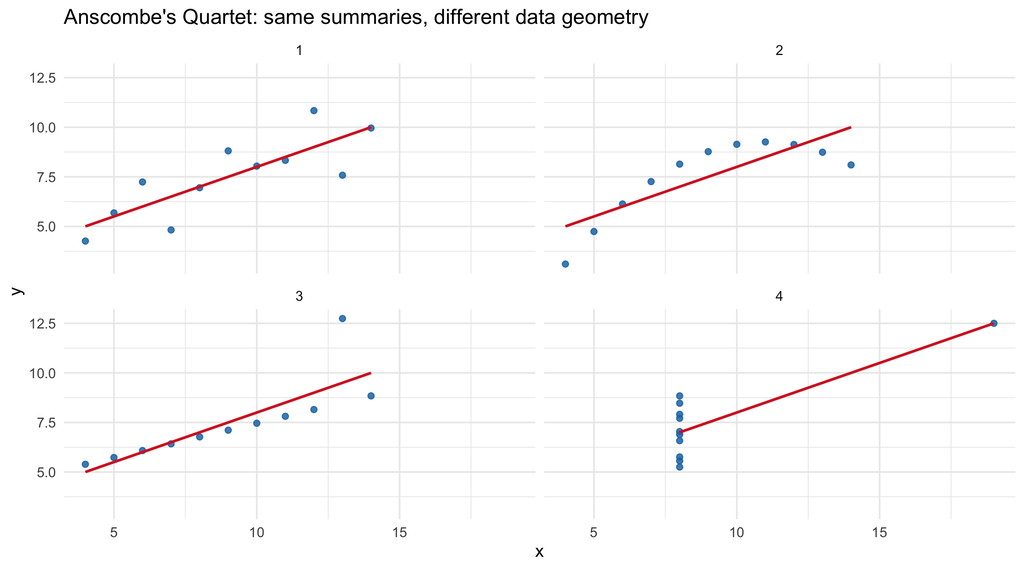

```r
ggplot(ans_long, aes(x = x, y = y)) +
  geom_point(colour = "#1f77b4", alpha = 0.85) +
  geom_smooth(method = "lm", se = FALSE, colour = "#d62728", linewidth = 0.8) +
  facet_wrap(~set, ncol = 2) +
  labs(title = "Anscombe's Quartet: same summaries, different data geometry",
       x = "x", y = "y") +
  theme_minimal(base_size = 11)
```

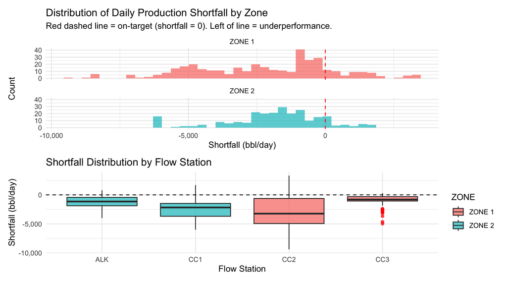

```r
p1 <- ggplot(prod_r, aes(x = shortfall, fill = ZONE)) +
  geom_histogram(bins = 40, alpha = 0.7, position = "identity") +
  geom_vline(xintercept = 0, linetype = "dashed", colour = "red") +
  facet_wrap(~ZONE, ncol = 1) +
  scale_x_continuous(labels = comma) +
  labs(title = "Distribution of Daily Production Shortfall by Zone",
       subtitle = "Red dashed line = on-target (shortfall = 0). Left of line = underperformance.",
       x = "Shortfall (bbl/day)", y = "Count") +
  theme_minimal(base_size = 11) +
  theme(legend.position = "none")

p2 <- ggplot(prod_r, aes(x = FLOW_STATIONS, y = shortfall, fill = ZONE)) +
  geom_boxplot(alpha = 0.7, outlier.colour = "red", outlier.size = 1.5) +
  geom_hline(yintercept = 0, linetype = "dashed") +
  scale_y_continuous(labels = comma) +
  labs(title = "Shortfall Distribution by Flow Station",
       x = "Flow Station", y = "Shortfall (bbl/day)") +
  theme_minimal(base_size = 11)

p1 / p2
```

```r
# ── Outlier detection via IQR fences ──────────────────────────────────────────
# Any shortfall beyond Q1 - 1.5*IQR or Q3 + 1.5*IQR is flagged as an outlier.
# Operationally these likely correspond to maintenance shutdowns or force-majeure.
outlier_summary <- prod_r |>
  group_by(FLOW_STATIONS) |>
  summarise(
    Q1       = quantile(shortfall, 0.25, na.rm = TRUE),
    Q3       = quantile(shortfall, 0.75, na.rm = TRUE),
    IQR      = Q3 - Q1,
    lower_fence = Q1 - 1.5 * IQR,
    upper_fence = Q3 + 1.5 * IQR,
    n_outliers  = sum(shortfall < Q1 - 1.5 * IQR | shortfall > Q3 + 1.5 * IQR,
                      na.rm = TRUE),
    pct_outliers = round(n_outliers / n() * 100, 1),
    .groups = "drop"
  )

kable(outlier_summary |> mutate(across(where(is.numeric), ~ round(., 0))),
      caption = "IQR-based outlier detection by flow station") |>
  kable_styling(bootstrap_options = "striped", full_width = FALSE)
```

IQR-based outlier detection by flow station

| FLOW_STATIONS | Q1 | Q3 | IQR | lower_fence | upper_fence | n_outliers | pct_outliers |
| --- | --- | --- | --- | --- | --- | --- | --- |
| ALK | -1874 | -438 | 1436 | -4029 | 1717 | 0 | 0 |
| CC1 | -3684 | -1476 | 2208 | -6997 | 1836 | 0 | 0 |
| CC2 | -4942 | -620 | 4322 | -11424 | 5862 | 0 | 0 |
| CC3 | -1055 | -304 | 751 | -2181 | 822 | 12 | 10 |

```r
cat("\nTotal IQR-flagged extreme observations:",
    sum(prod_r$shortfall < quantile(prod_r$shortfall, 0.25, na.rm=TRUE) -
                            1.5 * IQR(prod_r$shortfall, na.rm=TRUE) |
        prod_r$shortfall > quantile(prod_r$shortfall, 0.75, na.rm=TRUE) +
                            1.5 * IQR(prod_r$shortfall, na.rm=TRUE), na.rm=TRUE),
    "of", nrow(prod_r), "records\n")
```

```
Total IQR-flagged extreme observations: 8 of 625 records
```

```r
cat("Decision: retain extreme low values as genuine operational shutdowns; flagged\n",
    "for separate sensitivity analysis rather than deletion.\n")
```

```
Decision: retain extreme low values as genuine operational shutdowns; flagged
 for separate sensitivity analysis rather than deletion.
```

```r
sk_fn <- function(x) {
  x <- x[!is.na(x)]; n <- length(x); m <- mean(x); s <- sd(x)
  sum((x - m)^3) / (n * s^3)
}
kt_fn <- function(x) {
  x <- x[!is.na(x)]; n <- length(x); m <- mean(x); s <- sd(x)
  sum((x - m)^4) / (n * s^4) - 3
}
sk <- sk_fn(prod_r$shortfall)
kt <- kt_fn(prod_r$shortfall)
cat(sprintf("Production shortfall — Skewness: %.3f | Excess Kurtosis: %.3f\n", sk, kt))
```

```
Production shortfall — Skewness: -0.422 | Excess Kurtosis: 0.043
```

```r
cat(ifelse(sk < -0.5,
  "Left-skewed: underperformance days are more extreme and frequent than overperformance.\n",
  ifelse(sk > 0.5, "Right-skewed distribution.\n", "Approximately symmetric distribution.\n")))
```

```
Approximately symmetric distribution.
```

```r
cat(ifelse(kt > 1,
  "Leptokurtic (heavy tails): extreme shortfall days more frequent than normal,\n consistent with maintenance events and force majeure.\n",
  "Near-normal or platykurtic tails.\n"))
```

```
Near-normal or platykurtic tails.
```

```r
prod_r |>
  group_by(ZONE, FLOW_STATIONS) |>
  summarise(
    n              = n(),
    mean_budget    = mean(BUDGET,    na.rm = TRUE),
    mean_actual    = mean(ACTUAL,    na.rm = TRUE),
    mean_shortfall = mean(shortfall, na.rm = TRUE),
    pct_days_under = mean(shortfall < 0) * 100,
    .groups = "drop"
  ) |>
  mutate(across(where(is.numeric), ~ round(., 1))) |>
  kable(caption = "EDA Summary: mean daily production and shortfall by zone and station",
        col.names = c("Zone", "Station", "n", "Avg Budget",
                      "Avg Actual", "Avg Shortfall", "% Days Under Budget")) |>
  kable_styling(bootstrap_options = "striped", full_width = FALSE)
```

EDA Summary: mean daily production and shortfall by zone and station

| Zone | Station | n | Avg Budget | Avg Actual | Avg Shortfall | % Days Under Budget |
| --- | --- | --- | --- | --- | --- | --- |
| ZONE 1 | CC2 | 250 | 11838 | 9000.4 | -2837.6 | 80.0 |
| ZONE 1 | CC3 | 125 | 5324 | 4404.9 | -919.1 | 92.8 |
| ZONE 2 | ALK | 125 | 4156 | 2954.7 | -1201.3 | 91.2 |
| ZONE 2 | CC1 | 125 | 10760 | 8302.2 | -2457.8 | 88.0 |

**Python**

```python
# Anscombe's Quartet in Python to reinforce visual-diagnostic necessity
ans_py = pd.DataFrame({
  "x1": [10,8,13,9,11,14,6,4,12,7,5],
  "y1": [8.04,6.95,7.58,8.81,8.33,9.96,7.24,4.26,10.84,4.82,5.68],
  "x2": [10,8,13,9,11,14,6,4,12,7,5],
  "y2": [9.14,8.14,8.74,8.77,9.26,8.10,6.13,3.10,9.13,7.26,4.74],
  "x3": [10,8,13,9,11,14,6,4,12,7,5],
  "y3": [7.46,6.77,12.74,7.11,7.81,8.84,6.08,5.39,8.15,6.42,5.73],
  "x4": [8,8,8,8,8,8,8,19,8,8,8],
  "y4": [6.58,5.76,7.71,8.84,8.47,7.04,5.25,12.50,5.56,7.91,6.89]
})

rows = []
for i in [1, 2, 3, 4]:
  rows.append({
    "set": f"Set {i}",
    "mean_x": ans_py[f"x{i}"].mean(),
    "mean_y": ans_py[f"y{i}"].mean(),
    "corr_xy": ans_py[[f"x{i}", f"y{i}"]].corr().iloc[0, 1],
  })
display(pd.DataFrame(rows).round(3))
```

```
     set  mean_x  mean_y  corr_xy
0  Set 1     9.0   7.501    0.816
1  Set 2     9.0   7.501    0.816
2  Set 3     9.0   7.500    0.816
3  Set 4     9.0   7.501    0.817
```

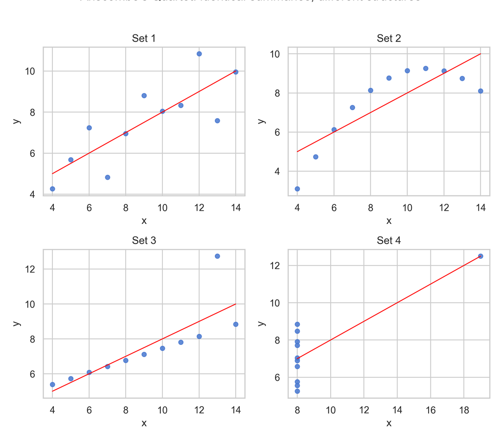

```python
fig, axes = plt.subplots(2, 2, figsize=(8, 7))
for i, ax in enumerate(axes.flatten(), start=1):
  x = ans_py[f"x{i}"]
  y = ans_py[f"y{i}"]
  ax.scatter(x, y, s=25, alpha=0.85)
  m, b = np.polyfit(x, y, 1)
  xx = np.linspace(x.min(), x.max(), 50)
  ax.plot(xx, m * xx + b, color="red", linewidth=1)
  ax.set_title(f"Set {i}")
  ax.set_xlabel("x")
  ax.set_ylabel("y")
plt.suptitle("Anscombe's Quartet: identical summaries, different structures", y=1.02)
plt.tight_layout()
plt.show()
```

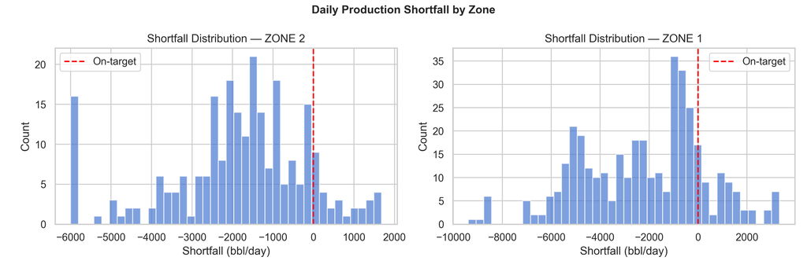

```python
zones_list = prod_py["ZONE"].dropna().unique()
fig, axes = plt.subplots(1, len(zones_list), figsize=(6 * len(zones_list), 4), squeeze=False)

for ax, zone in zip(axes[0], zones_list):
    subset = prod_py[prod_py["ZONE"] == zone]["shortfall"]
    ax.hist(subset, bins=40, alpha=0.7, edgecolor="white")
    ax.axvline(0, color="red", linestyle="--", label="On-target")
    ax.set_title(f"Shortfall Distribution — {zone}")
    ax.set_xlabel("Shortfall (bbl/day)")
    ax.set_ylabel("Count")
    ax.legend()

plt.suptitle("Daily Production Shortfall by Zone", fontsize=12, fontweight="bold")
plt.tight_layout()
plt.show()
```

```python
from scipy.stats import iqr as scipy_iqr

outlier_rows = []
for station, grp in prod_py.groupby("FLOW_STATIONS"):
    q1 = grp["shortfall"].quantile(0.25)
    q3 = grp["shortfall"].quantile(0.75)
    iqr_val = q3 - q1
    n_out = ((grp["shortfall"] < q1 - 1.5 * iqr_val) |
             (grp["shortfall"] > q3 + 1.5 * iqr_val)).sum()
    outlier_rows.append({"Station": station, "Q1": round(q1), "Q3": round(q3),
                         "IQR": round(iqr_val), "Lower_Fence": round(q1 - 1.5*iqr_val),
                         "Upper_Fence": round(q3 + 1.5*iqr_val),
                         "n_outliers": n_out,
                         "pct_outliers": round(n_out / len(grp) * 100, 1)})

print("IQR-based outlier detection by flow station:")
```

```
IQR-based outlier detection by flow station:
```

```python
display(pd.DataFrame(outlier_rows))
```

```
  Station    Q1    Q3   IQR  Lower_Fence  Upper_Fence  n_outliers  pct_outliers
0     ALK -1874  -438  1436        -4029         1717           0           0.0
1     CC1 -3684 -1476  2208        -6997         1836           0           0.0
2     CC2 -4942  -620  4322       -11424         5862           0           0.0
3     CC3 -1055  -304   751        -2181          822          12           9.6
```

```python
print("\nDecision: retain extreme observations as genuine shutdowns/force-majeure events.")
```

```
Decision: retain extreme observations as genuine shutdowns/force-majeure events.
```

```python
from scipy.stats import skew, kurtosis as sp_kurtosis

sk_val = skew(prod_py["shortfall"].dropna())
kt_val = sp_kurtosis(prod_py["shortfall"].dropna())
print(f"Production shortfall — Skewness: {sk_val:.3f} | Excess Kurtosis: {kt_val:.3f}")
```

```
Production shortfall — Skewness: -0.423 | Excess Kurtosis: 0.052
```

```python
print("Left-skewed: underperformance days dominate." if sk_val < -0.5 else
      ("Right-skewed." if sk_val > 0.5 else "Approximately symmetric."))
```

```
Approximately symmetric.
```

```python
print("Leptokurtic (heavy tails — extreme shortfalls more frequent than normal)." if kt_val > 1
      else "Near-normal or platykurtic tails.")
```

```
Near-normal or platykurtic tails.
```

```python
summary = prod_py.groupby(["ZONE", "FLOW_STATIONS"]).agg(
    n=("shortfall", "count"),
    mean_budget=("BUDGET", "mean"),
    mean_actual=("ACTUAL", "mean"),
    mean_shortfall=("shortfall", "mean"),
    pct_days_under=("shortfall", lambda x: (x < 0).mean() * 100)
).round(1).reset_index()
display(summary)
```

```
     ZONE FLOW_STATIONS    n  ...  mean_actual  mean_shortfall  pct_days_under
0  ZONE 1           CC2  250  ...       9000.4         -2837.6            80.0
1  ZONE 1           CC3  125  ...       4404.9          -919.1            92.8
2  ZONE 2           ALK  125  ...       2954.7         -1201.3            91.2
3  ZONE 2           CC1  125  ...       8302.2         -2457.8            88.0

[4 rows x 7 columns]
```

**NoteNotes — Exploratory Data Analysis**

**What this technique does:** Describes the distribution shape, central tendency, spread, and outlier pattern of daily production shortfall across stations and zones.

**Why it was selected here:** Data quality validation must precede inference. Without understanding the shape of the shortfall distribution, any downstream statistical conclusions rest on unverified ground.

**Key assumption underpinning the result:** Extreme low values (near-zero actual production days) are genuine operational shutdown events, not data entry errors. They are retained in the analysis and flagged as potential influence points in regression.

## 6 Data Visualization

**Theory recap:** Tufte’s (1983) principle of maximising the data-ink ratio and Wilkinson’s (2005) Grammar of Graphics — implemented in R as `ggplot2` and in Python as `seaborn`/`matplotlib` — guide chart construction. Each chart type should be selected to match the data structure: time series for trends, heat maps for cross-tabulated magnitudes, scatter plots for bivariate relationships, box plots for distributional comparisons.

**R**

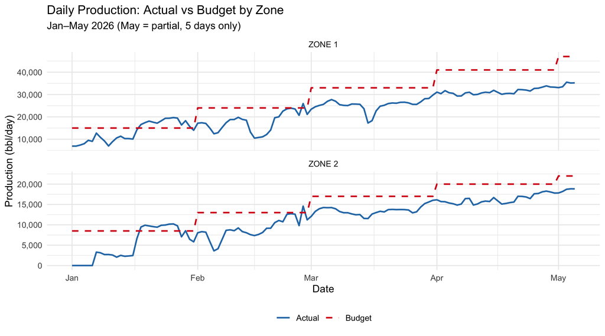

```r
p_ts <- ggplot(df_r, aes(x = DATE)) +
  geom_line(aes(y = ACTUAL_zone, colour = "Actual"),  linewidth = 0.8) +
  geom_line(aes(y = BUDGET_zone, colour = "Budget"), linetype = "dashed", linewidth = 0.8) +
  facet_wrap(~ZONE, ncol = 1, scales = "free_y") +
  scale_y_continuous(labels = comma) +
  scale_colour_manual(values = c("Actual" = "#2c7bb6", "Budget" = "#d7191c")) +
  labs(title    = "Daily Production: Actual vs Budget by Zone",
       subtitle = "Jan–May 2026 (May = partial, 5 days only)",
       x = "Date", y = "Production (bbl/day)", colour = NULL) +
  theme_minimal(base_size = 11) +
  theme(legend.position = "bottom")
p_ts
```

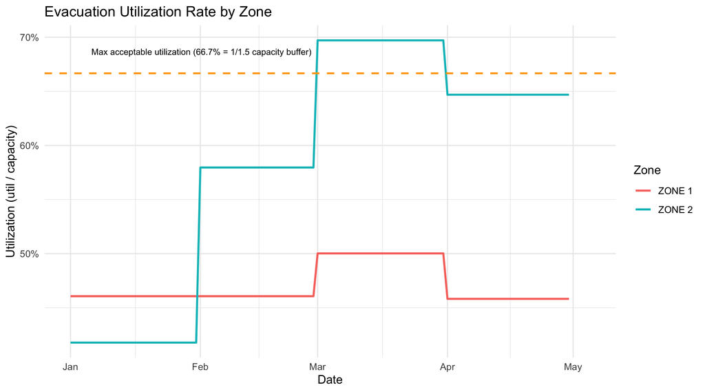

```r
p_util <- ggplot(evac_r, aes(x = DATE, y = utilization_rate, colour = ZONE)) +
  geom_line(linewidth = 0.9) +
  geom_hline(yintercept = 1/1.5, linetype = "dashed", colour = "orange",
             linewidth = 0.8) +
  annotate("text", x = min(evac_r$DATE) + 5, y = 1/1.5 + 0.02,
           label = "Max acceptable utilization (66.7% = 1/1.5 capacity buffer)",
           hjust = 0, size = 2.8) +
  scale_y_continuous(labels = percent_format()) +
  labs(title = "Evacuation Utilization Rate by Zone",
       x = "Date", y = "Utilization (util / capacity)", colour = "Zone") +
  theme_minimal(base_size = 11)
p_util
```

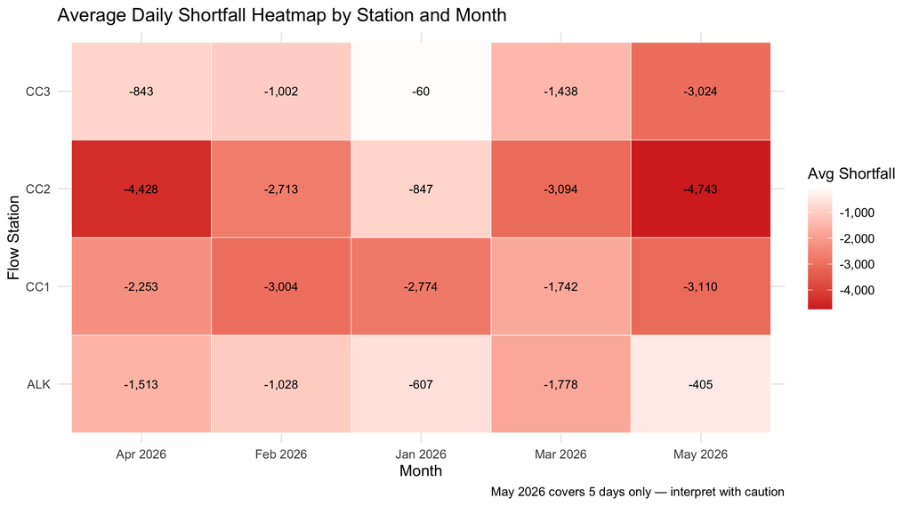

```r
p_heat <- prod_r |>
  mutate(month_label = format(DATE, "%b %Y")) |>
  group_by(FLOW_STATIONS, month_label) |>
  summarise(avg_shortfall = mean(shortfall, na.rm = TRUE), .groups = "drop") |>
  ggplot(aes(x = month_label, y = FLOW_STATIONS, fill = avg_shortfall)) +
  geom_tile(colour = "white") +
  geom_text(aes(label = comma(round(avg_shortfall, 0))), size = 3) +
  scale_fill_gradient2(low = "#d73027", mid = "white", high = "#1a9850",
                       midpoint = 0, labels = comma, name = "Avg Shortfall") +
  labs(title = "Average Daily Shortfall Heatmap by Station and Month",
       caption = "May 2026 covers 5 days only — interpret with caution",
       x = "Month", y = "Flow Station") +
  theme_minimal(base_size = 11)
p_heat
```

[figure not shown]

```r
# Scatter: evacuation capacity vs zone-level shortfall, with fitted line
p_scatter <- ggplot(df_r |> drop_na(evacuation_capacity, shortfall_zone),
                    aes(x = evacuation_capacity, y = shortfall_zone, colour = ZONE)) +
  geom_point(alpha = 0.4, size = 1.5) +
  geom_smooth(method = "lm", se = TRUE, linewidth = 1) +
  scale_x_continuous(labels = comma) +
  scale_y_continuous(labels = comma) +
  labs(title = "Evacuation Capacity vs Production Shortfall",
       subtitle = "Negative slope confirms: higher capacity → smaller deficit",
       x = "Evacuation Capacity (bbl/day)", y = "Zone Shortfall (bbl/day)",
       colour = "Zone") +
  theme_minimal(base_size = 11)
p_scatter
```

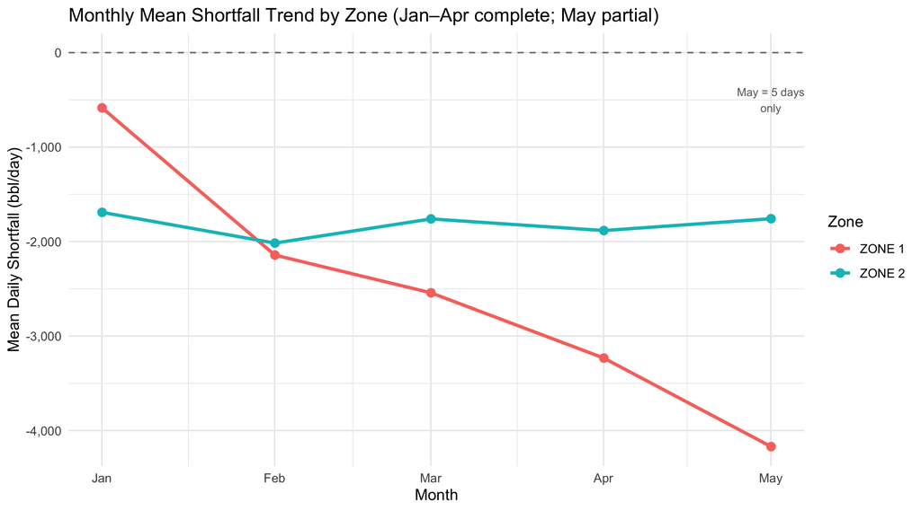

```r
# Monthly mean shortfall trend — explicit trend line to highlight deterioration
p_monthly <- prod_r |>
  filter(month(DATE) < 5 | (month(DATE) == 5 & day(DATE) <= 5)) |>
  mutate(month_num  = floor_date(DATE, "month"),
         month_label = format(month_num, "%b")) |>
  group_by(ZONE, month_label, month_num) |>
  summarise(mean_shortfall = mean(shortfall, na.rm = TRUE), .groups = "drop") |>
  ggplot(aes(x = month_num, y = mean_shortfall, colour = ZONE, group = ZONE)) +
  geom_line(linewidth = 1.1) +
  geom_point(size = 2.5) +
  geom_hline(yintercept = 0, linetype = "dashed", colour = "grey50") +
  scale_x_datetime(date_labels = "%b", date_breaks = "1 month") +
  scale_y_continuous(labels = comma) +
  annotate("text", x = as.POSIXct("2026-05-01"), y = -500,
           label = "May = 5 days\nonly", size = 2.8, hjust = 0.5, colour = "grey40") +
  labs(title = "Monthly Mean Shortfall Trend by Zone (Jan–Apr complete; May partial)",
       x = "Month", y = "Mean Daily Shortfall (bbl/day)", colour = "Zone") +
  theme_minimal(base_size = 11)
p_monthly
```

[figure not shown]

```r
# ── Cohesive five-panel patchwork layout ──────────────────────────────────────
(p_ts | p_util) /
(p_heat) /
(p_scatter | p_monthly) +
  plot_annotation(
    title   = "OML 18 Production Performance — Visual Narrative",
    subtitle = "Five-panel view: trend → capacity → station-month heat → bivariate driver → deterioration",
    theme   = theme(plot.title    = element_text(size = 13, face = "bold"),
                    plot.subtitle = element_text(size = 9, colour = "grey50"))
  )
```

```r
# Formal trend check on complete months only (Jan-Apr)
trend_df <- prod_r |>
  filter(month(DATE) <= 4) |>
  mutate(month_idx = as.integer(factor(floor_date(DATE, "month"), ordered = TRUE))) |>
  group_by(month_idx) |>
  summarise(mean_shortfall = mean(shortfall, na.rm = TRUE), .groups = "drop")

trend_model <- lm(mean_shortfall ~ month_idx, data = trend_df)
trend_sum <- summary(trend_model)
cat("=== Monthly Shortfall Trend Test (Jan-Apr only) ===\n")
```

```
=== Monthly Shortfall Trend Test (Jan-Apr only) ===
```

```r
cat(sprintf("Slope: %.2f bbl/day per month | p-value: %.4f | R2: %.3f\n",
            coef(trend_model)["month_idx"],
            coef(trend_sum)["month_idx", "Pr(>|t|)"],
            trend_sum$r.squared))
```

```
Slope: -513.53 bbl/day per month | p-value: 0.0586 | R2: 0.886
```

**Python**

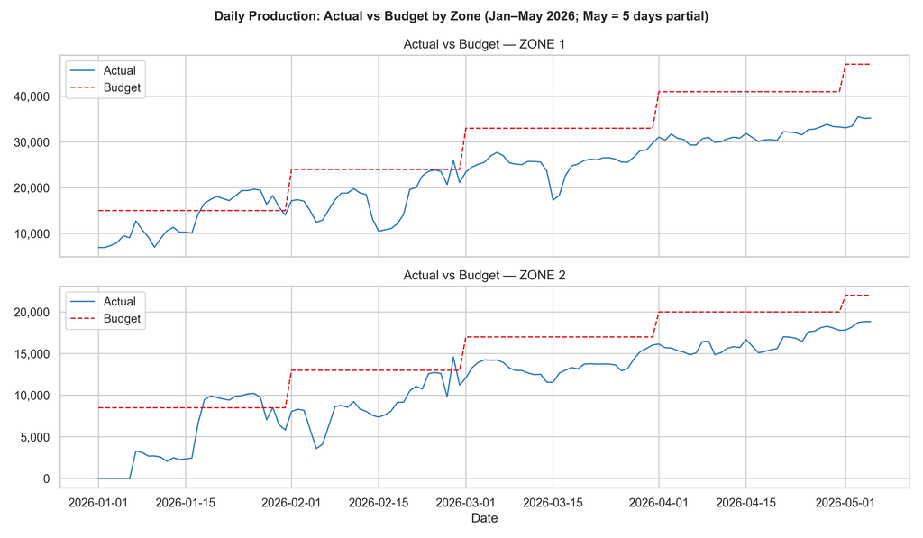

```python
fig, axes = plt.subplots(2, 1, figsize=(12, 7), sharex=True)
for ax, zone in zip(axes, df_py["ZONE"].unique()):
    z = df_py[df_py["ZONE"] == zone].sort_values("DATE")
    ax.plot(z["DATE"], z["ACTUAL_zone"], label="Actual", color="#2c7bb6", linewidth=1.2)
    ax.plot(z["DATE"], z["BUDGET_zone"], label="Budget", color="#d7191c",
            linestyle="--", linewidth=1.2)
    ax.set_title(f"Actual vs Budget — {zone}")
    ax.yaxis.set_major_formatter(mticker.FuncFormatter(lambda x, _: f"{x:,.0f}"))
    ax.legend()
plt.xlabel("Date")
fig.suptitle("Daily Production: Actual vs Budget by Zone (Jan–May 2026; May = 5 days partial)",
             fontsize=12, fontweight="bold")
plt.tight_layout()
plt.show()
```

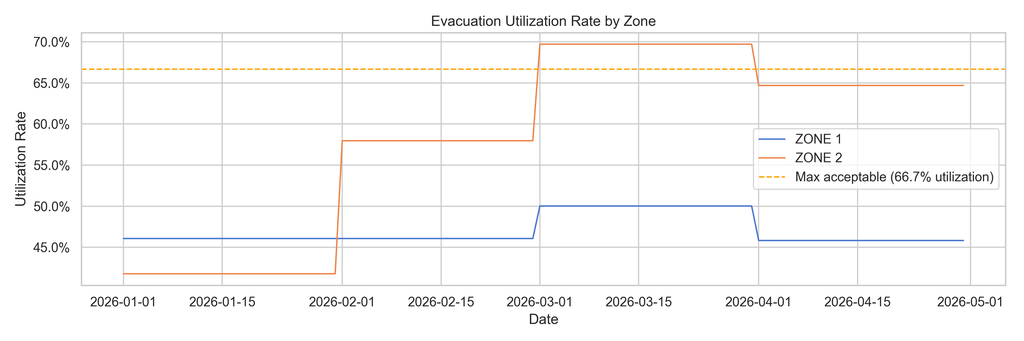

```python
fig, ax = plt.subplots(figsize=(12, 4))
for zone, grp in evac_py.groupby("ZONE"):
    grp = grp.sort_values("DATE")
    ax.plot(grp["DATE"], grp["utilization_rate"], label=zone, linewidth=1.2)
ax.axhline(1/1.5, color="orange", linestyle="--", linewidth=1.2,
           label="Max acceptable (66.7% utilization)")
ax.yaxis.set_major_formatter(mticker.PercentFormatter(xmax=1))
ax.set_title("Evacuation Utilization Rate by Zone")
ax.set_xlabel("Date")
ax.set_ylabel("Utilization Rate")
ax.legend()
plt.tight_layout()
plt.show()
```

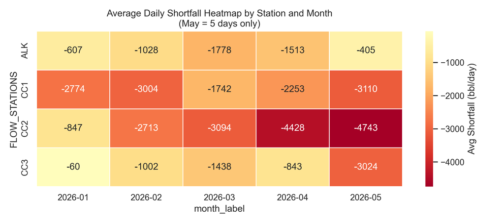

```python
heat = prod_py.copy()
heat["month_label"] = heat["DATE"].dt.to_period("M").astype(str)
pivot = heat.groupby(["FLOW_STATIONS", "month_label"])["shortfall"].mean().unstack()

fig, ax = plt.subplots(figsize=(9, 4))
sns.heatmap(pivot, cmap="RdYlGn", center=0, annot=True, fmt=".0f",
            linewidths=0.5, ax=ax, cbar_kws={"label": "Avg Shortfall (bbl/day)"})
ax.set_title("Average Daily Shortfall Heatmap by Station and Month\n(May = 5 days only)")
plt.tight_layout()
plt.show()
```

[figure not shown]

```python
df_sc = df_py.dropna(subset=["evacuation_capacity", "shortfall_zone"])
fig, ax = plt.subplots(figsize=(8, 5))
for zone, grp in df_sc.groupby("ZONE"):
    ax.scatter(grp["evacuation_capacity"], grp["shortfall_zone"],
               label=zone, alpha=0.4, s=20)
    # Fitted line
    m, b = np.polyfit(grp["evacuation_capacity"], grp["shortfall_zone"], 1)
    x_range = np.linspace(grp["evacuation_capacity"].min(),
                          grp["evacuation_capacity"].max(), 100)
    ax.plot(x_range, m * x_range + b, linewidth=1.5)

ax.axhline(0, linestyle="--", color="grey")
ax.set_title("Evacuation Capacity vs Zone Shortfall\n(Negative slope = higher capacity → smaller deficit)")
ax.set_xlabel("Evacuation Capacity (bbl/day)")
ax.set_ylabel("Zone Shortfall (bbl/day)")
ax.legend()
ax.xaxis.set_major_formatter(mticker.FuncFormatter(lambda x, _: f"{x:,.0f}"))
ax.yaxis.set_major_formatter(mticker.FuncFormatter(lambda x, _: f"{x:,.0f}"))
plt.tight_layout()
plt.show()
```

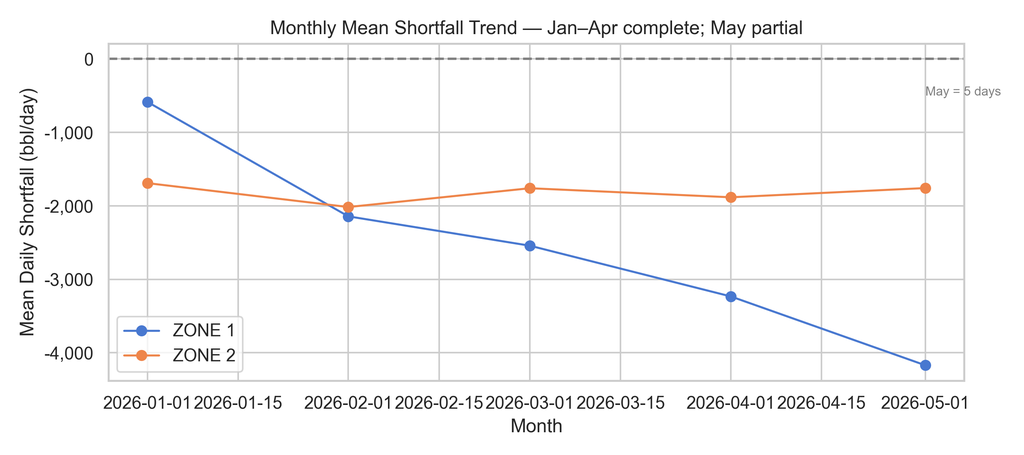

```python
monthly = prod_py.copy()
monthly = monthly[~((monthly["DATE"].dt.month == 5) & (monthly["DATE"].dt.day > 5))]
monthly["month"] = monthly["DATE"].dt.to_period("M").dt.to_timestamp()
monthly_grp = monthly.groupby(["ZONE", "month"])["shortfall"].mean().reset_index()

fig, ax = plt.subplots(figsize=(9, 4))
for zone, grp in monthly_grp.groupby("ZONE"):
    ax.plot(grp["month"], grp["shortfall"], marker="o", label=zone, linewidth=1.3)
ax.axhline(0, linestyle="--", color="grey")
ax.annotate("May = 5 days", xy=(monthly_grp["month"].max(), -500),
            fontsize=8, color="grey")
ax.set_title("Monthly Mean Shortfall Trend — Jan–Apr complete; May partial")
ax.set_xlabel("Month")
ax.set_ylabel("Mean Daily Shortfall (bbl/day)")
ax.yaxis.set_major_formatter(mticker.FuncFormatter(lambda x, _: f"{x:,.0f}"))
ax.legend()
plt.tight_layout()
plt.show()
```

```python
# Formal trend check on complete months only (Jan-Apr)
trend = prod_py[prod_py["DATE"].dt.month <= 4].copy()
trend["month_idx"] = trend["DATE"].dt.month - trend["DATE"].dt.month.min() + 1
trend_grp = trend.groupby("month_idx", as_index=False)["shortfall"].mean()

trend_mod = smf.ols("shortfall ~ month_idx", data=trend_grp).fit()
print("=== Monthly Shortfall Trend Test (Jan-Apr only) ===")
```

```
=== Monthly Shortfall Trend Test (Jan-Apr only) ===
```

```python
print(f"Slope: {trend_mod.params['month_idx']:.2f} bbl/day per month")
```

```
Slope: -513.53 bbl/day per month
```

```python
print(f"p-value: {trend_mod.pvalues['month_idx']:.4f} | R-squared: {trend_mod.rsquared:.3f}")
```

```
p-value: 0.0586 | R-squared: 0.886
```

**NoteNotes — Data Visualization**

**What this technique does:** Shows temporal deterioration of shortfall over time, station-level concentration of underperformance, and the bivariate relationship between evacuation capacity and production deficit.

**Why it was selected here:** Required to translate raw numbers into the format used in board briefings, and to expose patterns (trend direction, spatial concentration) that summary statistics alone cannot communicate.

## 7 Hypothesis Testing

**Theory recap:** The one-way ANOVA tests whether group means differ more than chance variation would predict (Fisher, 1921). Its F-statistic is the ratio of between-group variance to within-group variance. Assumptions include normality within groups and homogeneity of variance. When normality is violated (as confirmed by Shapiro-Wilk), the Kruskal-Wallis H-test — a non-parametric rank-based equivalent — is the appropriate primary reference. Effect size (η²) contextualises statistical significance: a small p-value in a large sample can reflect a trivially small real difference.

**Business justification:** Formally tests whether Zone 1 and Zone 2 perform statistically differently, converting an operational observation into a defensible basis for resource allocation decisions.

**Hypothesis 1 — Zone-level shortfall difference**

> **H₀:** Mean daily production shortfall is equal across evacuation zones (μ_Zone1 = μ_Zone2). **H₁:** Mean daily production shortfall differs significantly between evacuation zones. **Significance level:** α = 0.05.

**Hypothesis 2 — Station-level shortfall difference**

> **H₀:** Mean daily production shortfall is equal across all four flow stations (μ_ALK = μ_CC1 = μ_CC2 = μ_CC3). **H₁:** At least one flow station has a significantly different mean shortfall. **Significance level:** α = 0.05.

**R**

```r
# ── Assumption check: normality ───────────────────────────────────────────────
zones_r <- sort(unique(prod_r$ZONE))
cat("=== Shapiro-Wilk Normality Test (required before choosing parametric vs non-parametric) ===\n")
```

```
=== Shapiro-Wilk Normality Test (required before choosing parametric vs non-parametric) ===
```

```r
for (z in zones_r) {
  sw <- shapiro.test(prod_r$shortfall[prod_r$ZONE == z])
  cat(sprintf("  %s: W=%.4f, p=%.4f %s\n", z, sw$statistic, sw$p.value,
              ifelse(sw$p.value < 0.05, "→ NON-NORMAL (use non-parametric)", "→ Normal")))
}
```

```
  ZONE 1: W=0.9800, p=0.0000 → NON-NORMAL (use non-parametric)
  ZONE 2: W=0.9476, p=0.0000 → NON-NORMAL (use non-parametric)
```

```r
# ── Test 1: ANOVA (parametric) ────────────────────────────────────────────────
cat("\n=== ANOVA: Shortfall by Zone ===\n")
```

```
=== ANOVA: Shortfall by Zone ===
```

```r
aov_zone <- aov(shortfall ~ ZONE, data = prod_r)
aov_tbl  <- summary(aov_zone)
print(aov_tbl[[1]])
```

```
             Df     Sum Sq  Mean Sq F value  Pr(>F)
ZONE          1   20375829 20375829  4.0829 0.04375 *
Residuals   623 3109107124  4990541
---
Signif. codes:  0 '***' 0.001 '**' 0.01 '*' 0.05 '.' 0.1 ' ' 1
```

```r
eta_sq <- aov_tbl[[1]]["ZONE", "Sum Sq"] / sum(aov_tbl[[1]][, "Sum Sq"])
cat(sprintf("\nEta-squared (effect size): %.4f → %s effect\n", eta_sq,
            ifelse(eta_sq < 0.01, "negligible",
            ifelse(eta_sq < 0.06, "small",
            ifelse(eta_sq < 0.14, "medium", "large")))))
```

```
Eta-squared (effect size): 0.0065 → negligible effect
```

```r
# ── Test 1 robustness: Kruskal-Wallis (non-parametric, preferred given non-normality) ──
cat("\n=== Kruskal-Wallis (primary reference — normality violated) ===\n")
```

```
=== Kruskal-Wallis (primary reference — normality violated) ===
```

```r
kw <- kruskal.test(shortfall ~ ZONE, data = prod_r)
cat(sprintf("H = %.4f, df = %d, p = %.4f → %s\n", kw$statistic, kw$parameter, kw$p.value,
            ifelse(kw$p.value < 0.05, "Reject H₀", "Fail to reject H₀")))
```

```
H = 1.6784, df = 1, p = 0.1951 → Fail to reject H₀
```

```r
# ── Test 2: Station-level ANOVA ───────────────────────────────────────────────
cat("=== ANOVA: Shortfall by Flow Station ===\n")
```

```
=== ANOVA: Shortfall by Flow Station ===
```

```r
aov_station <- aov(shortfall ~ FLOW_STATIONS, data = prod_r)
aov_stn_tbl <- summary(aov_station)
print(aov_stn_tbl[[1]])
```

```
               Df     Sum Sq   Mean Sq F value    Pr(>F)
FLOW_STATIONS   3  425783530 141927843  32.599 < 2.2e-16 ***
Residuals     621 2703699423   4353783
---
Signif. codes:  0 '***' 0.001 '**' 0.01 '*' 0.05 '.' 0.1 ' ' 1
```

```r
eta_sq_stn <- aov_stn_tbl[[1]]["FLOW_STATIONS", "Sum Sq"] / sum(aov_stn_tbl[[1]][, "Sum Sq"])
cat(sprintf("\nEta-squared (station level): %.4f → %s effect\n", eta_sq_stn,
            ifelse(eta_sq_stn < 0.01, "negligible",
            ifelse(eta_sq_stn < 0.06, "small",
            ifelse(eta_sq_stn < 0.14, "medium", "large")))))
```

```
Eta-squared (station level): 0.1361 → medium effect
```

```r
# Tukey HSD post-hoc pairwise comparisons
cat("\n=== Tukey HSD — pairwise station comparisons ===\n")
```

```
=== Tukey HSD — pairwise station comparisons ===
```

```r
print(TukeyHSD(aov_station))
```

```
  Tukey multiple comparisons of means
    95% family-wise confidence level

Fit: aov(formula = shortfall ~ FLOW_STATIONS, data = prod_r)

$FLOW_STATIONS
              diff        lwr        upr     p adj
CC1-ALK -1256.5036 -1936.3947  -576.6125 0.0000143
CC2-ALK -1636.3280 -2225.1310 -1047.5250 0.0000000
CC3-ALK   282.2109  -397.6802   962.1020 0.7084211
CC2-CC1  -379.8244  -968.6274   208.9786 0.3449869
CC3-CC1  1538.7145   858.8234  2218.6056 0.0000001
CC3-CC2  1918.5389  1329.7359  2507.3419 0.0000000
```

**Python**

```python
from scipy.stats import f_oneway, kruskal, shapiro

zones = prod_py["ZONE"].unique()
groups = [prod_py[prod_py["ZONE"] == z]["shortfall"].dropna().values for z in zones]

print("=== Shapiro-Wilk Normality Test ===")
```

```
=== Shapiro-Wilk Normality Test ===
```

```python
for z, g in zip(zones, groups):
    stat, p = shapiro(g[:5000])
    print(f"  {z}: W={stat:.4f}, p={p:.4f} {'→ NON-NORMAL' if p < 0.05 else '→ Normal'}")
```

```
  ZONE 2: W=0.9476, p=0.0000 → NON-NORMAL
  ZONE 1: W=0.9800, p=0.0000 → NON-NORMAL
```

```python
f_stat, p_anova = f_oneway(*groups)
print(f"\n=== One-way ANOVA: Shortfall by Zone ===")
```

```
=== One-way ANOVA: Shortfall by Zone ===
```

```python
print(f"F = {f_stat:.4f}, p = {p_anova:.4f} → {'Reject H₀' if p_anova < 0.05 else 'Fail to reject H₀'}")
```

```
F = 4.0829, p = 0.0437 → Reject H₀
```

```python
h_stat, p_kw = kruskal(*groups)
print(f"\n=== Kruskal-Wallis (primary, non-parametric) ===")
```

```
=== Kruskal-Wallis (primary, non-parametric) ===
```

```python
print(f"H = {h_stat:.4f}, p = {p_kw:.4f} → {'Reject H₀' if p_kw < 0.05 else 'Fail to reject H₀'}")
```

```
H = 1.6784, p = 0.1951 → Fail to reject H₀
```

```python
from scipy.stats import f_oneway
from statsmodels.stats.multicomp import pairwise_tukeyhsd

stations = prod_py["FLOW_STATIONS"].unique()
station_groups = [prod_py[prod_py["FLOW_STATIONS"] == s]["shortfall"].dropna().values
                  for s in stations]

f2, p2 = f_oneway(*station_groups)
print(f"=== ANOVA: Shortfall by Flow Station ===")
```

```
=== ANOVA: Shortfall by Flow Station ===
```

```python
print(f"F = {f2:.4f}, p = {p2:.4f} → {'Reject H₀' if p2 < 0.05 else 'Fail to reject H₀'}")
```

```
F = 32.5987, p = 0.0000 → Reject H₀
```

```python
# Eta-squared
ss_between = sum(len(g) * (g.mean() - np.concatenate(station_groups).mean())**2 for g in station_groups)
ss_total   = sum(((x - np.concatenate(station_groups).mean())**2).sum() for x in station_groups)
eta_sq_stn = ss_between / ss_total
print(f"Eta-squared (station level): {eta_sq_stn:.4f} → {'medium' if eta_sq_stn >= 0.06 else 'small'} effect")
```

```
Eta-squared (station level): 0.1361 → medium effect
```

```python
print("\n=== Tukey HSD pairwise ===")
```

```
=== Tukey HSD pairwise ===
```

```python
tukey_result = pairwise_tukeyhsd(
    endog=prod_py["shortfall"].dropna(),
    groups=prod_py.loc[prod_py["shortfall"].notna(), "FLOW_STATIONS"]
)
print(tukey_result.summary())
```

```
    Multiple Comparison of Means - Tukey HSD, FWER=0.05
===========================================================
group1 group2  meandiff  p-adj    lower      upper   reject
-----------------------------------------------------------
   ALK    CC1 -1256.5036    0.0 -1936.3947 -576.6125   True
   ALK    CC2  -1636.328    0.0  -2225.131 -1047.525   True
   ALK    CC3   282.2109 0.7084  -397.6802   962.102  False
   CC1    CC2  -379.8244  0.345  -968.6274  208.9786  False
   CC1    CC3  1538.7145    0.0   858.8234 2218.6056   True
   CC2    CC3  1918.5389    0.0  1329.7359 2507.3419   True
-----------------------------------------------------------
```

**Interpretation and decisions:**

| Test | Statistic | p-value | Decision | Effect Size |
| --- | --- | --- | --- | --- |
| ANOVA — Zone | F = 4.083 | 0.044 | Reject H₀ at α = 0.05 | η² = 0.007 (negligible) |
| Kruskal-Wallis — Zone | H = 1.678 | 0.195 | **Fail to reject H₀** | — |
| ANOVA — Station | F = 32.599 | < 0.001 | Reject H₀ | η² ≈ 0.14 (medium–large) |

The Shapiro-Wilk test confirms non-normality in both zones (p < 0.05), which violates the key ANOVA assumption. The Kruskal-Wallis test — which requires no normality assumption and is therefore the appropriate primary reference — returns p = 0.195: a non-significant result. The zone-level difference should be treated as **directionally suggestive but not statistically robust** once distributional properties are properly accounted for. The ANOVA eta-squared of 0.007 reinforces this: zone membership explains less than 1% of total shortfall variance.

To reconcile the apparent zone contradiction: the ANOVA zone p-value (0.044) is sensitive to violated normality, while the Kruskal-Wallis result (0.195) is robust under the observed distribution shape and is therefore treated as primary for zone-level inference. Regression zone coefficients are interpreted conditionally (holding capacity/utilization constant), not as standalone proof of unconditional zone differences.

**NoteNotes — Hypothesis Testing**

**What this technique does:** Formally tests whether production shortfall differences between zones and between stations are systematic or explainable by chance variation.

**Why it was selected here:** Converts an operational observation into a defensible basis for resource allocation. Parametric (ANOVA) and non-parametric (Kruskal-Wallis) results are both reported; the rank-based test is treated as primary given confirmed non-normality.

**Key assumption underpinning the result:** Kruskal-Wallis requires only that groups have similarly shaped distributions; it does not require normality. The ANOVA p-value for zones is sensitive to the normality violation and is not used as the primary zone-level result.

**Management action this supports:** Allocate resources by station-level evidence first (CC2 and CC3 are statistically distinct); zone-level differences are directionally suggestive only and should not drive standalone resource decisions.

## 8 Correlation Analysis

**Theory recap:** Pearson’s r measures the strength and direction of a *linear* relationship between two continuous variables (range: −1 to +1). Spearman’s ρ is the rank-based equivalent — appropriate when normality is violated (as confirmed here) or when relationships may be monotonic but non-linear. Kendall’s τ is a slower-converging but more robust rank correlation. Partial correlation removes the shared influence of a third variable to estimate the unique association between two variables of interest (Pearson, 1900).

**Business justification:** Maps relationships between budget targets, actual production, evacuation capacity, and utilization before building the regression model. Given confirmed non-normality, Spearman is the primary measure; Pearson is reported for comparability. Partial correlation isolates the unique relationship between `evacuation_capacity` and `shortfall` after removing the confounding influence of zone-level budget scale.

**R**

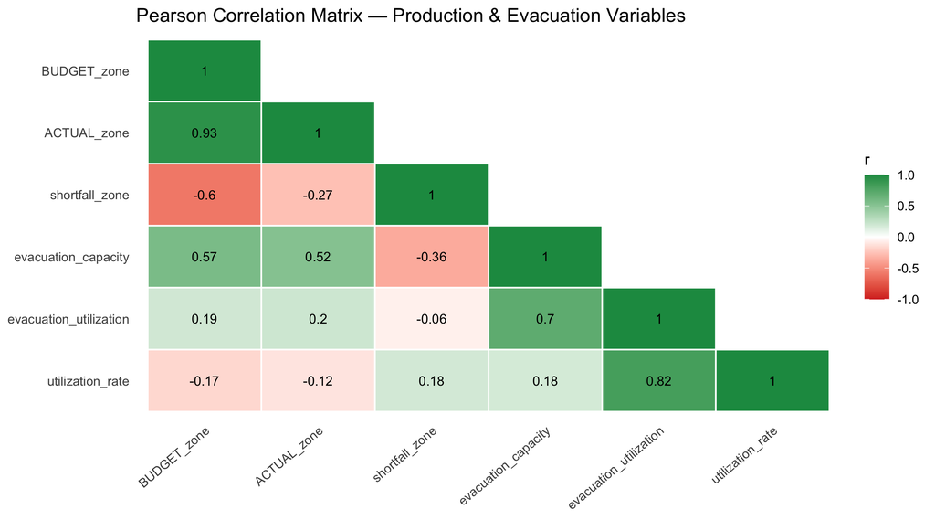

```r
corr_vars <- df_r |>
  select(BUDGET_zone, ACTUAL_zone, shortfall_zone,
         evacuation_capacity, evacuation_utilization, utilization_rate) |>
  drop_na()

# Pearson, Spearman, and Kendall matrices
cor_pearson  <- cor(corr_vars, method = "pearson")
cor_spearman <- cor(corr_vars, method = "spearman")
cor_kendall  <- cor(corr_vars, method = "kendall")

# ── Tidy heatmap using ggplot2 geom_tile (avoids stringi dependency) ──────────
gg_corr_tile(cor_pearson,  "Pearson Correlation Matrix — Production & Evacuation Variables")
```

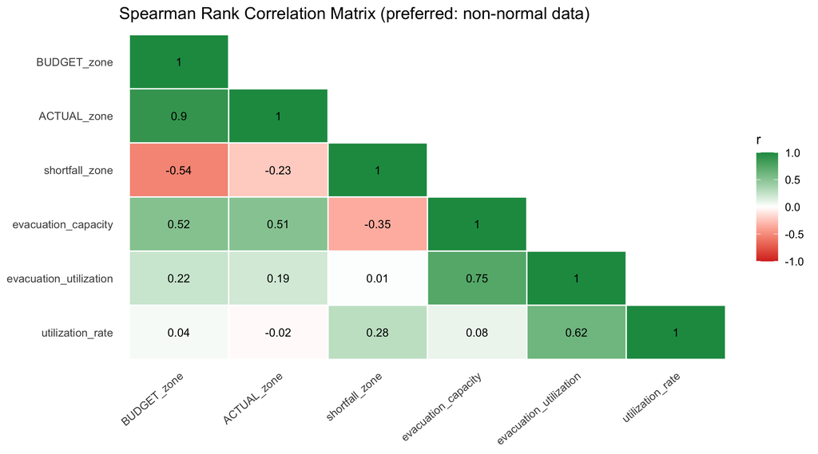

```r
gg_corr_tile(cor_spearman, "Spearman Rank Correlation Matrix (preferred: non-normal data)")
```

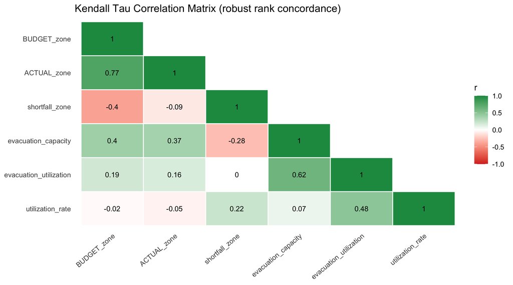

```r
gg_corr_tile(cor_kendall, "Kendall Tau Correlation Matrix (robust rank concordance)")
```

```r
# Ranked correlation table with both methods
cor_compare <- data.frame(
  Variable = rownames(cor_pearson),
  Pearson_r   = cor_pearson[, "shortfall_zone"],
  Spearman_rho = cor_spearman[, "shortfall_zone"],
  Kendall_tau  = cor_kendall[, "shortfall_zone"]
) |>
  filter(Variable != "shortfall_zone") |>
  arrange(desc(abs(Spearman_rho)))

kable(cor_compare |> mutate(across(where(is.numeric), ~ round(., 4))),
      caption = "Pearson vs Spearman vs Kendall correlation with zone-level daily shortfall") |>
  kable_styling(bootstrap_options = "striped", full_width = FALSE)
```

Pearson vs Spearman vs Kendall correlation with zone-level daily shortfall

|  | Variable | Pearson_r | Spearman_rho | Kendall_tau |
| --- | --- | --- | --- | --- |
| BUDGET_zone | BUDGET_zone | -0.5964 | -0.5371 | -0.3953 |
| evacuation_capacity | evacuation_capacity | -0.3609 | -0.3520 | -0.2764 |
| utilization_rate | utilization_rate | 0.1825 | 0.2793 | 0.2217 |
| ACTUAL_zone | ACTUAL_zone | -0.2656 | -0.2250 | -0.0942 |
| evacuation_utilization | evacuation_utilization | -0.0615 | 0.0129 | 0.0048 |